# Informe Proyecto 2023-I

# Tema del proyecto

Expectativas de los estudiantes de UTEC 2023-1 acerca del uso de la inteligencia artificial en la medicina

# **Introducción**

## **Relevancia**

En medio de avances tecnológicos acelerados, la inteligencia artificial se ha convertido en una herramienta prometedora en diversas áreas, incluida la medicina. Para comprender su impacto y potencial en este campo, es fundamental analizar el conocimiento y uso de IA entre los jóvenes hoy en día. Conocer las expectativas de una generación que ha crecido en un entorno digital y tecnológico nos podría dar un alcance cercano a lo que podría ser el futuro de la medicina basado en la tecnología.

## **Objetivos**

1.- Analizar el conocimiento y uso de inteligencia artificial de los estudiantes de UTEC del periodo 2023-1.

2.- Identificar la relevancia que tendría la inteligencia artificial en la medicina según estudiantes de UTEC del periodo 2023-1, así como el interés de los mismos en participar en su implementación en el campo.

3.- Determinar las áreas médicas específicas en que los estudiantes de UTEC en el periodo 2023-1 creen que podría ser mejor aprovechada la IA.

4.- Identificar la disposición de los estudiantes de UTEC del periodo 2023-1 de ser atendidos por una inteligencia artificial ante una futura patología teniendo en cuenta el coste económico.

5.- Determinar los factores limitantes del uso de la IA en la medicina según la perspectiva de los estudiantes de UTEC en el periodo 2023-1.

## **Contexto**

La IA consiste en un conjunto de algoritmos programados para facilitar la automatización, optimizar el análisis de datos y potenciar la eficiencia de un proceso. Dentro de las aplicaciones que esta tiene se encuentra el campo de la medicina, pues, según expertos, la IA podría convertirse en parte central de los sistemas de salud digitales que dan forma y respaldan la medicina moderna (IBM,2021).

# **Datos**

## **Recolección de datos**

Para la obtención de datos realizamos un Google Forms con preguntas alineadas a nuestros objetivos. Para el llenado del formulario tuvimos en cuenta restricciones para cada una de las preguntas, de esta manera nuestra base de datos no contendría muchos datos para limpiar. Para poder optimizar el llenado de encuestas utilizamos un código QR que redirigía a los estudiantes directamente a nuestro formulario. El proceso fue esperar a algunos en puntos concurridos en la universidad, como: ascensores, pisos de ventas de snack o de recreación. Además, las horas cumplían un papel fundamental pues a partir del mediodía algunos utilizaban mucho más los comedores o pisos de recraciòn. También actuamos virtualmente, compartiendo el link por redes sociales y enviando a través de correo electrónico de la universidad.

## **Población, muestra y muestreo**

Nuestro enfoque principal radica en dirigir nuestros esfuerzos hacia la población estudiantil que conforma la Universidad de Ingeniería y Tecnología (UTEC). Específicamente, nos dirigimos a aquellos estudiantes matriculados en el semestre 2023-1.

Con respecto a la muestra que utilizaremos para llevar a cabo nuestro estudio, está conformada por 183 estudiantes del ciclo 2023-I. Sin embargo, para ser más minuciosos y precisos en determinados análisis, se estarán utilizando 177 observaciones de la base de datos recolectada. Esto se especificará posteriormente.

El tipo de muestreo utilizado fue por conveniencia, por lo que no podemos afirmar una representatividad del 100% en nuestro estudio. Empero, durante el proceso nos aseguramos de contactar con estudiantes de todas las edades y del mayor número de carreras posibles para así tener diversidad en nuestra data y otorgarle representatividad a la muestra.

## **Variables**

> | Pregunta | Variable | Descripción | Tipo | Restricción |
> | --- | --- | --- | --- | --- |
> | Nombre Completo | Nombre | Nombre completo del encuestado | Categórica Nominal | No caracteres numéricos |
> | Correo Electrónico | Correo | Correo institucional del encuestado | Categórica Nominal | Su correo debe pertenecer a UTEC |
> | Edad | Edad | Edad del encuestado | Numérica Discreta | Entero Positivo y debe estar entre los 15 y 35 años |
> | Carrera | Carrera | La carrera que lleva el encuestado | Categórica Nominal | Solo carreras de la Universidad |
> | Ciclo Académico | Ciclo | Ciclo se encuentra el encuestado | Categórica Ordinal | Del primer a Décimo ciclo |
> | ¿Has escuchado sobre la IA? | Ha_Escuchado | Pregunta sobre el conocimiento de Inteligencia Artificial (AI) | Categórica Nominal | - |
> | ¿La IA es parte de tu vida cotidiana? (Asistentes de voz, GPS, etc) | IA_uso_cotidiano | Esta pregunta busca comprender si la inteligencia artificial (IA) forma parte de tu vida diaria a través de la utilización de tecnologías. | Categórica Nominal | - |
> | ¿Cuántas horas al día haces uso de la IA? (Asistentes de voz, GPS, chat GPT, etc) Por favor, usa el punto como separador decimal. | Horas_día | Esta pregunta representa las horas al día que utilizas inteligencia artificial en tu rutina como estudiante. | Numérica Continua | - |
> | ¿En qué campos de aplicación crees que pueda ser mejor aprovechada la IA? | Campos_aplicación | Es una pregunta de selección múltiple de como La IA puede ser mejor aprovechada en diversos campos de aplicación, como la medicina, la educación, comercio, alimentación y política . | Categórica Nominal | - |
> | ¿Piensas que la IA debería ser utilizada en el campo de la medicina? | Debe_usarse_medicina | Esta pregunta indica si la IA en el campo de la medicina tiene el potencial de ser beneficiosa para mejorar el diagnóstico, el tratamiento y la atención médica en general. Las alternativas son de afir… | Categórica Nominal | - |
> | ¿En cuál de los siguientes aspectos médicos crees que podría contribuir la IA? Marque todas las que considere correctas. | Aspecto_medicos | La pregunta busca conocer la opinión de los encuestados sobre los posibles campos en los que la inteligencia artificial podría tener un impacto positivo en el ámbito médico teniendo como alternativas … | Categórica Nominal | - |
> | En la siguiente escala, ¿Qué tan relevante crees que pueda ser la utilización de la IA en el campo de la medicina? | Relevancia_medicina | La pregunta busca evaluar la percepción de los encuestados sobre la relevancia (Va de NO RELEVANTE a MUY RELEVANTE) de utilizar inteligencia artificial en el campo de la medicina donde se solicita a l… | Categórica Ordinal | - |
> | ¿En cuántos años crees que la IA pueda consolidarse como un método efectivo para el diagnóstico/tratamiento de una patología? | Años_consolidacion | La pregunta busca obtener una opinión sobre el tiempo que se estima necesario para que la inteligencia artificial se consolide como un método efectivo en el diagnóstico y tratamiento de patologías | Numérica Continua | - |
> | ¿Crees que la IA pueda reemplazar eventualmente a un profesional de la salud? | Remplazara_médico | La pregunta busca obtener una opinión sobre la posibilidad de que la inteligencia artificial eventualmente reemplace a un profesional de la salud. Si bien la IA ha demostrado ser prometedora en divers… | Categórica Nominal | - |
> | ¿En qué rango de precio (soles) crees que costaría recibir atención de parte de una IA en una consulta médica ordinaria? | Rango_precio | La pregunta busca obtener una estimación del rango de precios en soles que se cree que podría tener la atención de una IA en una consulta médica ordinaria. Es importante tener en cuenta que los costos… | Numérica Continua | - |
> | ¿En caso de presentar una patología en el futuro y teniendo en cuenta la pregunta anterior, ¿estarías dispuesto a ser atendido por una IA y/o recibir tratamiento complementario con apoyo en una IA? | Disposicion_ser_atendido | La pregunta busca conocer la disposición del individuo a ser atendido por una IA y/o recibir tratamiento complementario con el apoyo de la inteligencia artificial en caso de presentar una patología en… | Categórica Nominal | - |
> | ¿Te interesaría ser parte del desarrollo y/o implementación de la IA en la medicina desde tu campo laboral? | Interes_desarrollo_IA | La pregunta busca conocer el interés del individuo en participar en el desarrollo y/o implementación de la inteligencia artificial en el campo de la medicina desde su campo laboral mediante tres alter… | Categórica Nominal | - |
> | ¿En qué orden de prioridad piensas que debería posicionarse el uso de IA a la hora de realizar un diagnóstico / tratamiento médico? | Orden_prioridad | La pregunta busca obtener la opinión sobre el orden de prioridad (1 representa máxima prioridad al 5 que representa mínima prioridad ) en el que se piensa que debería posicionarse el uso de la intelig… | Categórica Ordinal | - |
> | Cuál(es) de los siguientes factores crees que pueda(n) ser limitantes en la aplicación de la IA en la medicina a largo plazo? | Factores_limitantes | La pregunta busca identificar los factores que se consideran limitantes en la aplicación a largo plazo de la inteligencia artificial en la medicina. Los factores que podrían considerarse incluyen: Pre… | Categórica Nominal | - |

```r
if(!require(readr)){install.packages('readr')}
```

```r
if(!require(ggplot2)){install.packages('ggplot2')}
if(!require(dplyr)){install.packages('dplyr')}
if(!require(DescTools)){instal.packages('DescTools')}
if(!require(stringr)){instal.packages('stringr')}
library(stringr)
library(dplyr)
library(DescTools)
library(ggplot2)
library(readr)
```

```r
D1<- read_csv("Base_de_datos.csv")
BD <- D1
```

## Limpieza de datos:

#### Eliminamos la columna de Marca Temporal de la base de datos

```r
BD <- select(D1,-"Marca temporal")
```

#### Renombramos las variables

```r
names(BD) <- c("Nombre_Completo","Correo","Edad","Carrera","Ciclo","Ha_escuchado","IA_uso_cotidiano","Horas_dia","Campos_aplicacion","Debe_usarse_medicina","Aspectos_medicos","Relevancia_medicina","Años_consolidacion","Reemplazara_medico","Rango_precio","Disposicion_ser_atendido","Interes_desarrollo_IA","Orden_prioridad","Factores_limitantes")
```

Como en el formulario pusimos un rango de precio con un guion(“-”), debemos poner una cantidad equivalente del intervalo mostrado para realizar el análisis de datos. Esta cantidad fue la cantidad media entre el límite inferior y el superior.

```r
BD$Rango_precio=recode(BD$Rango_precio,'50 - 100'='75', '100 - 300'='200','300 - 500'='400','500 - 700'='600','700+'='800')
BD$Rango_precio<-as.numeric(BD$Rango_precio)
```

Observamos que una persona comentó que en 2025 años la IA se consolidará como un método efectivo para el diagnóstico/tratamiento de una enfermedad. Este resulta un dato no concordante con los demás, por lo que interpretamos que la persona se refería a que en el año 2025 la IA se consolidará. Por ello cambiamos “2025” por “2”. (2025-2023=2)

```r
BD$Años_consolidacion=as.character(BD$Años_consolidacion)
BD$Años_consolidacion=recode(BD$Años_consolidacion,'2025'='2')
BD$Edad=as.integer(BD$Edad)
BD$Años_consolidacion=as.integer(BD$Años_consolidacion)
```

A continuación, trabajaremos con las observaciones que tienen más datos incompletos. Es clave reconocer que casi todas las variables están vacías en estas observaciones debido a que una de las primeras preguntas del formulario fue: ¿Has escuchado sobre la inteligencia artificial?, y si su respuesta fue “No”, se les envió al final de la encuesta. Si bien no podemos eliminar los NAs, podemos modificarlos de la siguiente manera sin alterar los resultados:

Definimos que las personas que no han escuchado sobre la inteligencia artificial no hacen uso de ella en su vida diaria. Cabe resaltar que podríamos definir la variable Disposición_ser_atendido o Relevancia_medicina con respuestas negativas (“No” y “Poco relevante” respectivamente), pero estaríamos alterando nuestra base de datos, pues no podemos asegurar que los encuestados piensen así. Esto se debe a que al no haber escuchado acerca de la IA, no estamos seguros si opinan que será relevante o no en la medicina o si están dispuestos a ser atendidos por una ante una futura patología, ya que no la conocen.

```r
vec<-which(BD$Ha_escuchado=="No")
for (i in 1:length(vec)){
  BD[vec[i],7]="No"
  }
```

Ahora trabajaremos con las observaciones que tienen como respuesta “No” en la variable Debe_usarse_medicina, la cual hace referencia a si los encuestados piensan que la IA debería usarse en la medicina.

Primero, al poner que no creen que debería usarse en este campo, interpretamos que piensan que la IA no podrá reemplazar a un médico, que tendrá poca relevancia, que debería tomar una menor prioridad a la hora de realizar diagnósticos y/o tratamientos, y que no estarían dispuestos a ser atendidos por una IA o participar en su desarrollo en el campo de la medicina, por lo que modificamos esas variables:

```r
vec2<-which(BD$Debe_usarse_medicina=="No")
for (i in 1:length(vec2)){
  BD[vec2[i],12]="Poco relevante"
  BD[vec2[i],14]="No"
  BD[vec2[i],16]="No"
  BD[vec2[i],17]="No"
  BD[vec2[i],18]=5
  #5 representa la mínima prioridad

  }
```

A continuación, reemplazaremos todos los NA de la variable Horas_día por 0, debido a que existe una pregunta previa: ¿La IA es parte de tu vida cotidiana? y si la respuesta era “No”, se le abstenía al encuestado de responder la pregunta acerca de las horas de uso para no ser redundante.

Con la función sum comprobamos que ya no hay datos faltantes en la variable Horas_dia.

```r
vec2<-which(BD$IA_uso_cotidiano=="No")
for (i in 1:length(vec2)){
  BD[vec2[i],8]=0
}
sum(is.na(BD$Horas_dia))
```

```
## [1] 0
```

Terminado de hacer lo descrito anteriormente, nuestra base de datos estaría limpia, pues únicamente tenemos 3 entradas de texto en nuestra encuesta: el Nombre, Correo y Horas de uso de la IA al día (La cual fue corregida anteriormente). Nuestro formulario tenía restricciones para estas tres variables: en la variable Horas_dia solo se permitían números entre 0 y 24, en el correo solo se permitía correos de la institución y en el nombre no permitía números. Asimismo, no se permitía que un usuario hiciera la encuesta 2 veces, así que no hay datos repetidos.

Antes de pasar a nuestro análisis, aplicamos un recode en las variables orden prioridad y ciclo para un mejor manejo de datos posteriormente

```r
BD$Orden_prioridad=recode(BD$Orden_prioridad,'1'='Máxima prioridad', '2'='Notable prioridad','3'='Prioridad media','4'='Poca prioridad','5'='Mínima prioridad')
```

```r
BD$Ciclo<-recode(BD$Ciclo,'Primero'='1','Segundo'= '2','Tercer'='3','Cuarto'='4','Quinto'='5','Sexto'='6','Séptimo'='7','Octavo'='8','Noveno'='9','Décimo'='10')
```

## **Análisis descriptivo**

### Principales descriptores numéricos

#### Variables cuantitativas:

Edad, Horas_dia, Años_consolidacion, Rango_precio

```r
DN=BD
```

#### Tamaño efectivo de las variables

```r
length(na.omit(DN$Edad))
```

```
## [1] 183
```

```r
length(na.omit(DN$Horas_dia))
```

```
## [1] 183
```

```r
length(na.omit(DN$Años_consolidacion))
```

```
## [1] 174
```

```r
length(na.omit(DN$Rango_precio))
```

```
## [1] 174
```

### **1. Medidas de tendencia central:**

#### 1.1 Media o promedio o media aritmética (mean)

```r
mean(DN$Rango_precio, na.rm=T)
```

```
## [1] 282.0402
```

```r
mean(DN$Edad, na.rm=T)
```

```
## [1] 19.22404
```

```r
mean(DN$Horas_dia, na.rm=T)
```

```
## [1] 2.539617
```

```r
mean(DN$Años_consolidacion, na.rm=T)
```

```
## [1] 7.511494
```

#### 1.2 Mediana (median)

```r
median(DN$Años_consolidacion, na.rm=T)
```

```
## [1] 5
```

```r
median(DN$Edad, na.rm=T)
```

```
## [1] 19
```

```r
median(DN$Horas_dia, na.rm=T)
```

```
## [1] 2
```

```r
median(DN$Rango_precio, na.rm=T)
```

```
## [1] 200
```

### 1.3 Moda (Mode)

```r
Mode(DN$Edad, na.rm=T)
```

```
## [1] 18
## attr(,"freq")
## [1] 60
```

```r
Mode(DN$Horas_dia, na.rm=T)
```

```
## [1] 1
## attr(,"freq")
## [1] 40
```

```r
Mode(DN$Años_consolidacion, na.rm=T)
```

```
## [1] 5
## attr(,"freq")
## [1] 50
```

```r
Mode(DN$Rango_precio, na.rm=T)
```

```
## [1] 75
## attr(,"freq")
## [1] 57
```

### Interpretación:

Para la variable Edad, “18” es el valor que ocurre con mayor frecuencia. Nos representa que, de los estudiantes de UTEC del periodo 2023-1, hay tendencia en que tienen 18 años. De igual manera, el dato que más se repite en cuanto a las horas es 1. EN tercer lugar, gran parte de los encuestados piensas que en 5 años la IA se consolidará como un método efectivo para el diagnóstico/tratamiento de una enfermedad. Finalmente, el precio que más se repite es de 75 soles. (Intervalo de 0-200)

### **1. Medidas de dispersión:**

### Coeficiente de variación

```r
cv <- function(X){
  return(sd(X, na.rm = T) / mean(X, na.rm = T))
}
```

```r
cv(DN$Edad)
```

```
## [1] 0.08268196
```

```r
cv(DN$Horas_dia)
```

```
## [1] 1.068234
```

```r
cv(DN$Años_consolidacion)
```

```
## [1] 1.192184
```

```r
cv(DN$Rango_precio)
```

```
## [1] 0.7849663
```

### Interpretación

Observamos que la variable que más varía en nuestra base de datos son los años de consolidación de la IA en la medicina.

## **Gráficos de acuerdo a los objetivos**

#### **Objetivo 1: Analizar el conocimiento y uso de inteligencia artificial de los estudiantes de UTEC del periodo 2023-1.**

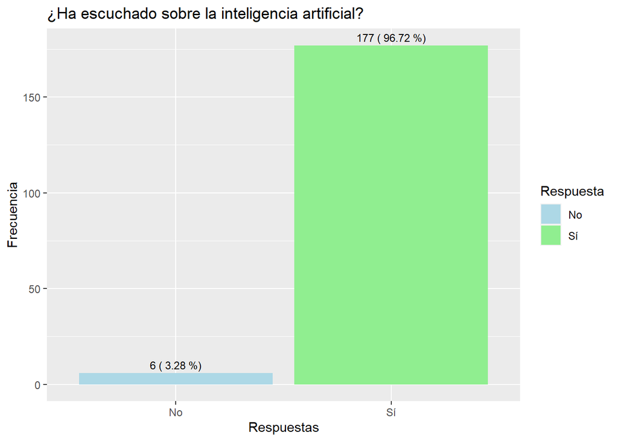

```r
tabla_respuestas2 <- table(BD$Ha_escuchado)
total_encuestados2 <- sum(tabla_respuestas2)

df_respuestas2 <- data.frame(Respuesta = names(tabla_respuestas2),
                            frecuencia = as.numeric(tabla_respuestas2))
df_respuestas2$porcentaje <- df_respuestas2$frecuencia/total_encuestados2 * 100
ggplot(data = df_respuestas2, aes(x = Respuesta, y = frecuencia, fill = Respuesta)) +
  geom_bar(stat = "identity") +
  labs(title = "¿Ha escuchado sobre la inteligencia artificial? ",
       x = "Respuestas", y = "Frecuencia") +
  scale_fill_manual(values = c("lightblue", "lightgreen")) +
  geom_text(aes(label = paste(frecuencia, "(", round(porcentaje, digits = 2), "%)")),
            vjust = -0.5, color = "black", size = 3)
```

*Gráfico 1: ¿Ha escuchado sobre la inteligencia artificial?*

### Interpretación:

Un 96.72% de los encuestados ha escuchado sobre la inteligencia artificial, mientras que solo un 3.28% de los encuestados no ha escuchado sobre ella. Esto se traduce únicamente a 6 personas que desconocen acerca del rubro.

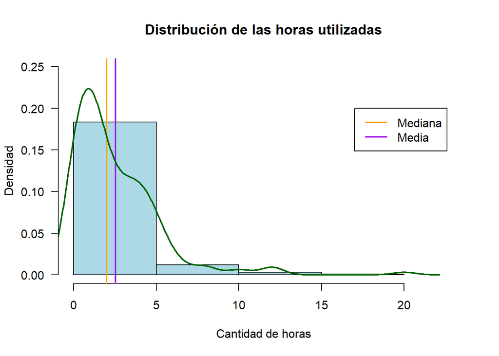

```r
X <- BD$Horas_dia[!is.na(BD$Horas_dia)]
media <- mean(X, na.rm = T)
mediana <- median(X, na.rm=T)

hist(X, breaks = 5, las = 1, xlim = c(0,23), ylim = c(0, 0.25), main = "Distribución de las horas utilizadas", xlab = "Cantidad de horas", ylab = "Densidad", probability = T,col="lightblue")

abline(v=media,col ="purple", lwd=2)
abline(v=mediana,col="orange", lwd=2)

lines(density(X), lwd = 2, col = "darkgreen")
legend(17,0.2,legend=c("Mediana","Media"),lwd=2,col=c("orange","purple"))
```

*Gráfico 2: Distribución de horas utilizadas*

### Interpretación:

En el gráfico vemos la representación de un histograma y un gráfico de densidad al mismo tiempo. Ambos gráficos coinciden en estár sesgados hacia la derecha, por lo que entendemos que la media es mayor a la mediana y que no muchos estudiantes usan la IA más de 10 horas.

#### **Objetivo 2: Identificar la relevancia que tendría la inteligencia artificial en la medicina según estudiantes de UTEC del periodo 2023-1, así como el interés de los mismos en participar en su implementación en el campo.**

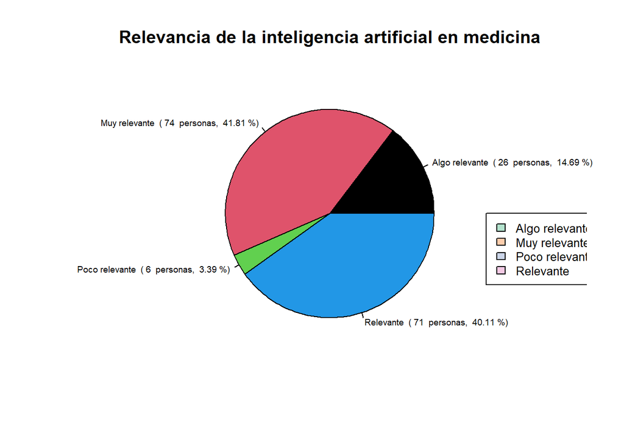

```r
tabla_respuestas <- table(BD$Relevancia_medicina)
porcentaje_relevantes <- prop.table(tabla_respuestas) * 100
porcentaje_redondeado <- round(porcentaje_relevantes, digits = 2)
cantidad_personas <- as.vector(tabla_respuestas)
colores <- rainbow(length(tabla_respuestas))
labels <- paste(names(tabla_respuestas), " (", cantidad_personas, " personas, ", porcentaje_redondeado, "%)")
pie(tabla_respuestas, labels = labels, col = palette("Pastel 2"), cex = 0.6)
legend(x = 1.2, y = 0, legend = names(tabla_respuestas), cex = 0.8, fill = palette("Pastel 2"))
title(main = "Relevancia de la inteligencia artificial en medicina")
```

*Gráfico 3: Relevancia de la inteligencia artificial en la medicina*

Nota: Fueron utilizadas 177 de 183 observaciones para la realización de este gráfico debido a que 6 encuestados no han escuchado sobre la IA y por ende, no tienen una respuesta a esta pregunta.

### Interpretación:

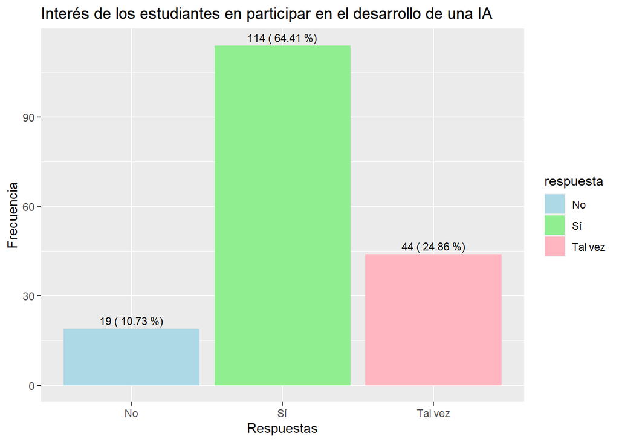

```r
tabla_respuestas1 <- table(BD$Interes_desarrollo_IA)

total_encuestados1 <- sum(tabla_respuestas1)

df_respuestas1 <- data.frame(respuesta = names(tabla_respuestas1),
                            frecuencia = as.numeric(tabla_respuestas1))

df_respuestas1$porcentaje <- df_respuestas1$frecuencia/total_encuestados1 * 100


ggplot(data = df_respuestas1, aes(x = respuesta, y = frecuencia, fill = respuesta)) +
  geom_bar(stat = "identity") +
  labs(title = "Interés de los estudiantes en participar en el desarrollo de una IA",
       x = "Respuestas", y = "Frecuencia") +
  scale_fill_manual(values = c("lightblue", "lightgreen","lightpink")) +
  geom_text(aes(label = paste(frecuencia, "(", round(porcentaje, digits = 2), "%)")),
            vjust = -0.5, color = "black", size = 3)
```

*Gráfico 4: Interés de los estudiantes en el desarrollo de la IA desde su campo laboral*

Nota: Fueron utilizadas 177 de 183 observaciones para la realización de este gráfico debido a que 6 encuestados no han escuchado sobre la IA y por ende, no tienen una respuesta a esta pregunta.

### Interpretación

Un 64.41% de los encuestados afirman que les gustaría ser parte del desarrollo/implementación de la IA en la medicina desde su campo laboral, un 24.86% presenta incertidumbre en hacerlo y 10.73% no desean participar en absoluto.

#### **Objetivo 3: Determinar las áreas médicas específicas en que los estudiantes de UTEC en el periodo 2023-1 creen que podría ser mejor aprovechada la IA.**

```r
Aplicación <- data.frame(Campos = c(BD$Campos_aplicacion))
```

```r
Aplicación$Campos<-str_split_fixed(Aplicación$Campos, ",", 6)
```

```r
Aplicaciones1<-str_trim(Aplicación$Campos,side="both")
ap <-table(Aplicaciones1)
```

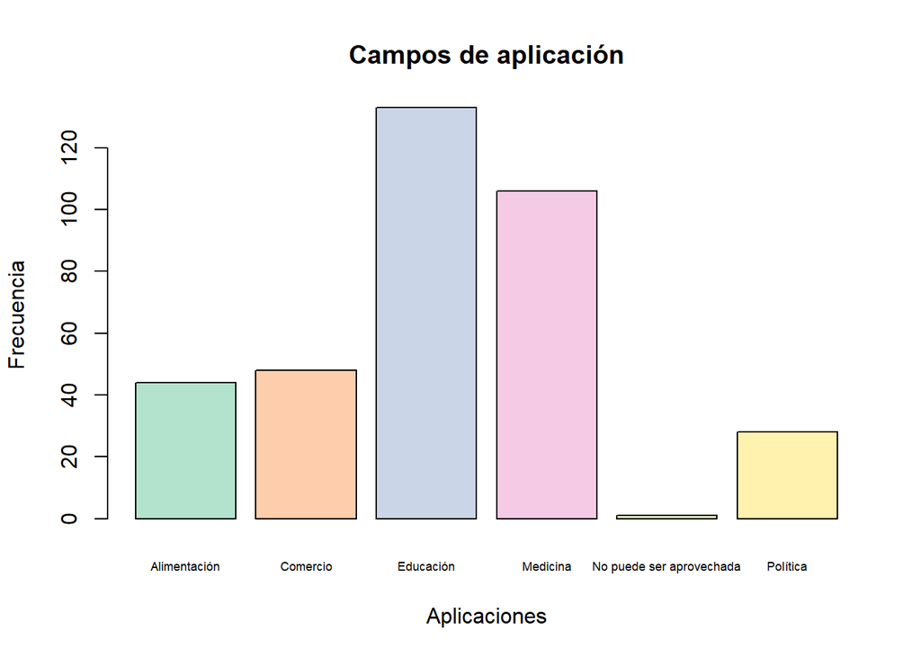

```r
barplot(table(Aplicaciones1[Aplicaciones1 != ""]), main = "Campos de aplicación",
        xlab = "Aplicaciones", ylab = "Frecuencia",  cex.names = 0.55,col=palette("Pastel 2"))
```

*Gráfico 5: Campos de Aplicación en los que sería relevante la IA*

Nota: Fueron utilizadas 177 de 183 observaciones para la realización de este gráfico debido a que 6 encuestados no han escuchado sobre la IA y por ende, no tienen una respuesta a esta pregunta.

### Interpretación

```r
Aspectos_medicos <- data.frame(Razones = c(BD$Aspectos_medicos))
Aspectos_medicos$Razones<-str_split_fixed(Aspectos_medicos$Razones, ",", 6)
Aspectos_medicos1<-str_trim(Aspectos_medicos$Razones,side="both")
```

```r
Vector<-data.frame(table(Aspectos_medicos1))
a<- as.numeric(Vector %>% filter(Aspectos_medicos1=="Estrategias de tratamiento") %>% select(Freq))
b<- as.numeric(Vector %>% filter(Aspectos_medicos1=="Análisis de datos genómicos") %>% select(Freq))
c<- as.numeric(Vector %>% filter(Aspectos_medicos1=="Robótica médica") %>% select(Freq))
d<- as.numeric(Vector %>% filter(Aspectos_medicos1=="Procesos hospitalarios") %>% select(Freq))
e<- as.numeric(Vector %>% filter(Aspectos_medicos1=="Desarrollo de fármacos") %>% select(Freq))
f<- as.numeric(Vector %>% filter(Aspectos_medicos1=="Planes salud mental") %>% select(Freq))
```

```r
Vector_Aspectos_grafico<-data.frame("Aspectos"=c(rep("Tratamiento",a),rep("Genética",b),rep("Robótica",c),rep("Hospitalización",d),rep("Farmacología",e),rep("Salud mental",f)))
```

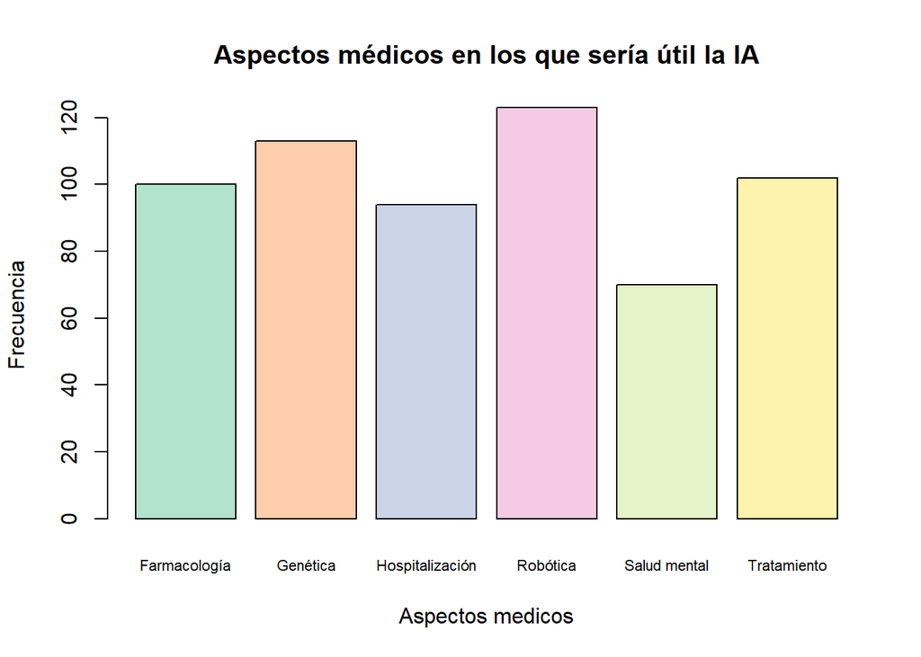

```r
barplot(table(Vector_Aspectos_grafico), main = "Aspectos médicos en los que sería útil la IA", xlab = "Aspectos medicos", ylab = "Frecuencia", cex.names = 0.7,col=palette("Pastel 2"))
```

*Gráfico 6: Aspectos médicos en los que sería relevante la IA*

Nota: Fueron utilizadas 174 de 183 observaciones para la realización de este gráfico debido a que 6 encuestados no han escuchado sobre la IA y por ende, no tienen una respuesta a esta pregunta. Además, 3 encuestados no piensan que la IA debería ser utilizada en la medicina, por lo que no participaron en esta pregunta.

### Interpretación

Observamos que los aspectos médicos específicos que los estudiantes encuentran más relevantes en la medicina son la robótica médica y el análisis de datos genómicos, mientras el que tiene menor relevancia en este contexto es el campo de salud mental.

#### **Objetivo 4: Identificar la disposición de los estudiantes de UTEC del periodo 2023-1 de ser atendidos por una inteligencia artificial ante una futura patología teniendo en cuenta el coste económico.**

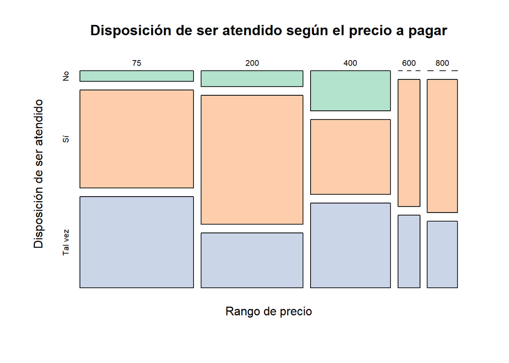

```r
mosaicplot(~BD$Rango_precio+BD$Disposicion_ser_atendido,off=8,xlab="Rango de precio",ylab="Disposición de ser atendido",main="Disposición de ser atendido según el precio a pagar",col=palette("Pastel 2"))
```

*Gráfico 7: Disposición de ser atendido por una IA segpun el precio*

Nota: Fueron utilizadas 177 de 183 observaciones para la obtención de los datos de la variable Disposicion_ser_atendido debido a que 6 encuestados no han escuchado sobre la IA y por ende, no tienen una respuesta a esta pregunta. Para la variable Rango_precio, se utilizaron 174 de 183 observaciones, pues, además de los 6 mencionados anteriormente, hubieron 3 encuestados que no creen que la medicina debería ser utilizada en el campo, por lo que no participaron en esta pregunta.

### Interpretación

Observamos que no hay relación clara entre el precio y la disposición. Se esperaría que, a mayor precio a pagar, menor sea la disposición, pero para los precios más altos (600 - 800) nos damos cuenta que es mayor la disposición de ser atendido. Sin embargo, los encuestados que creen que la implementación de una IA costará 400 soles cuentan con la mayor cantidad de respuestas negativas.

#### **Objetivo 5: Determinar los factores limitantes del uso de la IA en la medicina según la perspectiva de los estudiantes de UTEC en el periodo 2023-1.**

```r
Factores_Limitantes <- data.frame(FacLimitantes = c(BD$Factores_limitantes))
```

```r
Factores_Limitantes$FacLimitantes<-str_split_fixed(Factores_Limitantes$FacLimitantes, ",", 5) # Estamos
```

```r
Factores_Limitantes1<-str_trim(Factores_Limitantes$FacLimitantes,side="both")

R <- table(Factores_Limitantes1)
```

```r
Vector2<-data.frame(table(Factores_Limitantes1))
a2<- as.numeric(Vector2 %>% filter(Factores_Limitantes1=="Accesibilidad en zonas de bajos recursos") %>% select(Freq))
b2<- as.numeric(Vector2 %>% filter(Factores_Limitantes1=="Conflictos éticos") %>% select(Freq))
c2<- as.numeric(Vector2 %>% filter(Factores_Limitantes1=="Credibilidad y/o confianza de los pacientes") %>% select(Freq))
d2<- as.numeric(Vector2 %>% filter(Factores_Limitantes1=="Poca flexibilidad para diagnósticos/tratamientos") %>% select(Freq))
e2<- as.numeric(Vector2 %>% filter(Factores_Limitantes1=="Precio de implementación") %>% select(Freq))
```

```r
Vector_factores_grafico<-data.frame("Factores"=c(rep("Accesibilidad",a),rep("Ética",b),rep("Credibilidad",c),rep("Flexibilidad",d),rep("Precio",e)))
```

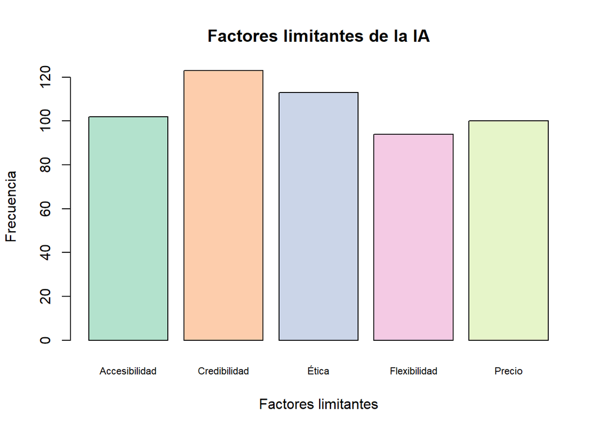

```r
barplot(table(Vector_factores_grafico), main = "Factores limitantes de la IA",
        xlab = "Factores limitantes", ylab = "Frecuencia", cex.names = 0.7,col=palette("Pastel 2"))
```

Nota: Fueron utilizadas 174 de 183 observaciones para la realización de este gráfico debido a que 6 encuestados no han escuchado sobre la IA y por ende, no tienen una respuesta a esta pregunta. Además, 3 encuestados no piensan que la IA debería ser utilizada en la medicina, por lo que no participaron en esta pregunta.

## GRÁFICOS GENERALES

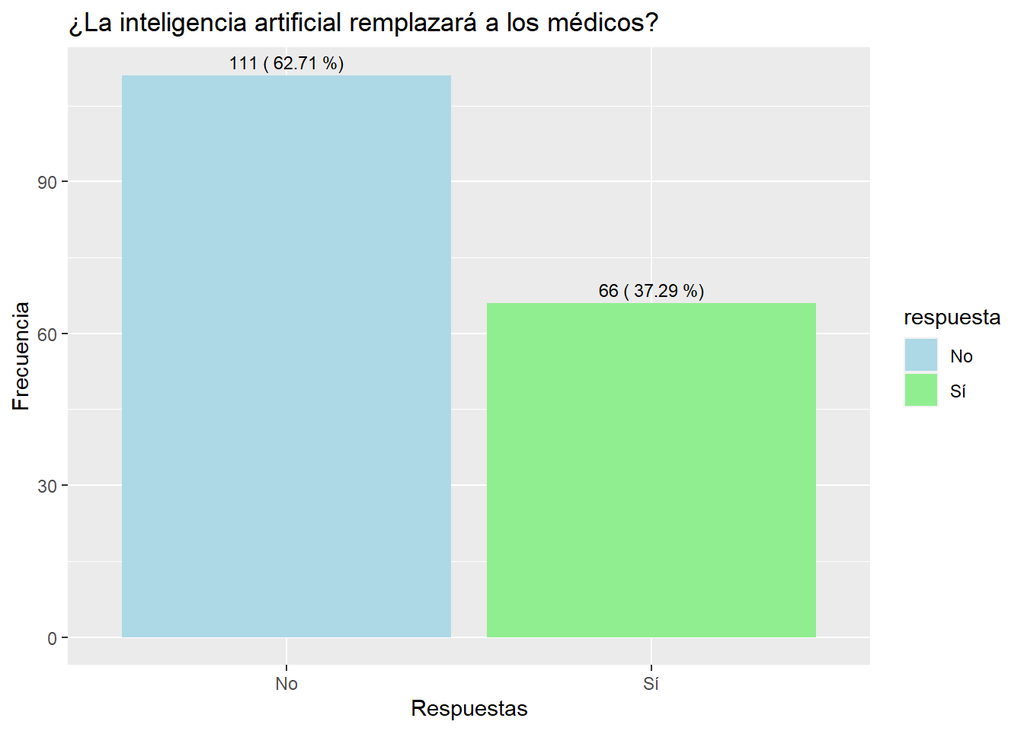

```r
tabla_respuestas <- table(BD$Reemplazara_medico)

total_encuestados <- sum(tabla_respuestas)

df_respuestas <- data.frame(respuesta = names(tabla_respuestas),
                            frecuencia = as.numeric(tabla_respuestas))

df_respuestas$porcentaje <- df_respuestas$frecuencia/total_encuestados * 100

ggplot(data = df_respuestas, aes(x = respuesta, y = frecuencia, fill = respuesta)) +
  geom_bar(stat = "identity") +
  labs(title = "¿La inteligencia artificial remplazará a los médicos?",
       x = "Respuestas", y = "Frecuencia") +
  scale_fill_manual(values = c("lightblue", "lightgreen")) +
  geom_text(aes(label = paste(frecuencia, "(", round(porcentaje, digits = 2), "%)")),
            vjust = -0.5, color = "black", size = 3)
```

*Gráfico 9: ¿La inteligencia artificial remplazará a los médicos?*

Nota: Fueron utilizadas 177 de 183 observaciones para la realización de este gráfico debido a que 6 encuestados no han escuchado sobre la IA y por ende, no tienen una respuesta a esta pregunta.

### Interpretación

Un 62.71% de los encuestados piensa que la IA no podrá reemplazar a los profesionales de la salud. Sin embargo, 37.29% de los participantes afirman que en un futuro sí lo harán.

```r
BD$Rango_precio <- as.numeric(BD$Rango_precio)
```

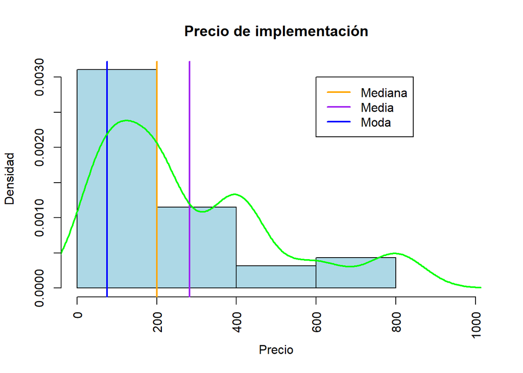

```r
X2 <- BD$Rango_precio[!is.na(BD$Rango_precio)]
media <- mean(X2, na.rm = T)
mediana <- median(X2, na.rm=T)
moda <- Mode(X2, na.rm=T)

hist(X2, breaks = 4, las = 3, xlim = c(0,1000), main = "Precio de implementación", xlab = "Precio", ylab = "Densidad", probability = T,col="lightblue")

abline(v=media,col ="purple", lwd=2)
abline(v=mediana,col="orange", lwd=2)
abline(v=moda,col="blue", lwd=2)

lines(density(X2), lwd = 2, col = "green")
legend(600,0.003,legend=c("Mediana","Media","Moda"),lwd=2,col=c("orange","purple","blue"))
```

*Gráfico 10: Precio de implementación-densidad.*

Nota: Fueron utilizadas 174 de 183 observaciones para la realización de este gráfico debido a que 6 encuestados no han escuchado sobre la IA y por ende, no tienen una respuesta a esta pregunta. Además, 3 encuestados no piensan que la IA debería ser utilizada en la medicina, por lo que no participaron en esta pregunta.

### Interpretación

Vemos que el gráfico está sesgado hacia la derecha, por lo que la media es mayor que la mediana y la mediana es mayor a la moda. Es decir, vemos que los precios entre 0 y 200 tienen la mayor frecuencia a pesar de que el promedio sea 282 aproximadamente (línea 285).

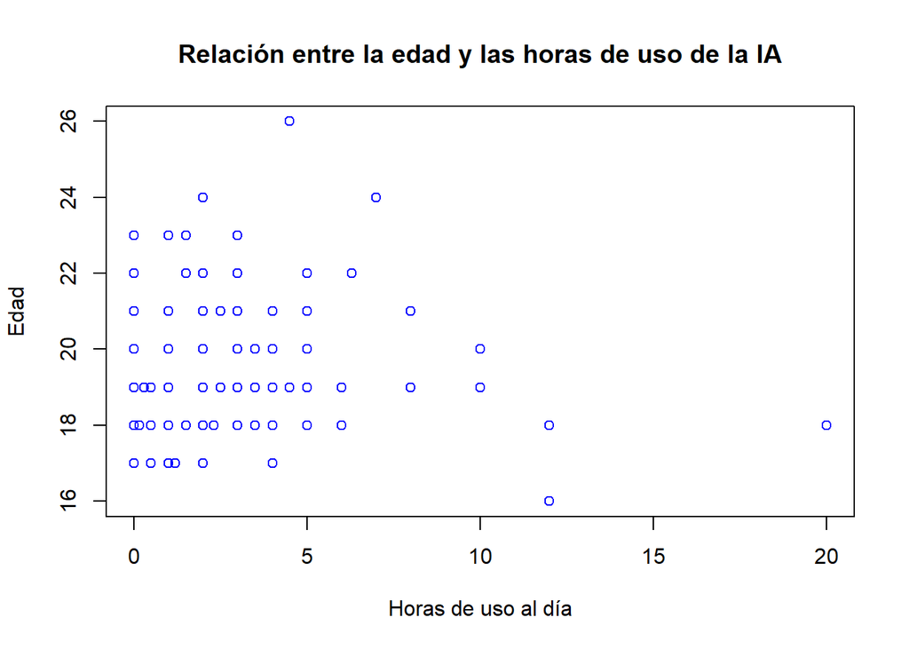

```r
plot(BD$Horas_dia,BD$Edad,col="blue",xlab="Horas de uso al día",ylab="Edad",main="Relación entre la edad y las horas de uso de la IA")
```

```r
cor.test(BD$Horas_dia,BD$Edad)
```

```
##
##  Pearson's product-moment correlation
##
## data:  BD$Horas_dia and BD$Edad
## t = 0.77141, df = 181, p-value = 0.4415
## alternative hypothesis: true correlation is not equal to 0
## 95 percent confidence interval:
##  -0.08854753  0.20063503
## sample estimates:
##        cor
## 0.05724439
```

*Gráfico 11: Relación entre la edad y las horas de uso de la IA*

### Interpretación

Observamos que no hay una relación directa entre la edad y las horas de uso de la IA. Esto lo comprobamos con el índice de correlación, la cual es de solo 5.72%

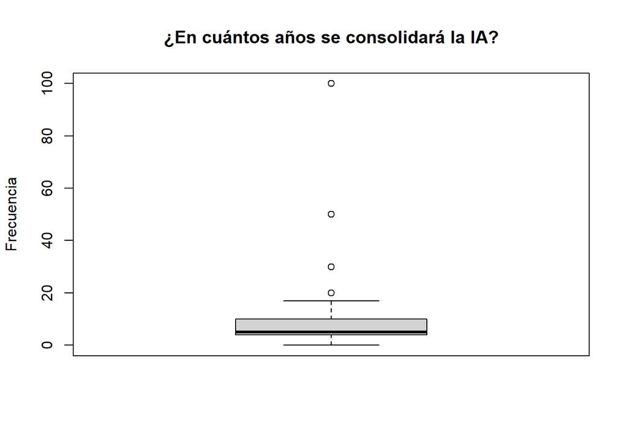

```r
grafico_años<-boxplot(BD$Años_consolidacion, main="¿En cuántos años se consolidará la IA?",ylab="Frecuencia")
```

*Gráfico 12: ¿En cuántos años se consolidará la IA?*

Nota: Fueron utilizadas 174 de 183 observaciones para la realización de este gráfico debido a que 6 encuestados no han escuchado sobre la IA y por ende, no tienen una respuesta a esta pregunta. Además, 3 encuestados no piensan que la IA debería ser utilizada en la medicina, por lo que no participaron en esta pregunta.

```r
grafico_años
```

```
## $stats
##      [,1]
## [1,]    0
## [2,]    4
## [3,]    5
## [4,]   10
## [5,]   17
##
## $n
## [1] 174
##
## $conf
##          [,1]
## [1,] 4.281323
## [2,] 5.718677
##
## $out
## [1]  20  20  30  20  20  50  20 100
##
## $group
## [1] 1 1 1 1 1 1 1 1
##
## $names
## [1] ""
```

### Interpretación

Nos damos cuenta de que para la variable años de consolidación, hay un mínimo de 4 datos atípicos. Sin embargo, el gráfico no se observa adecuadamente, por lo que eliminaremos temporalmente los datos atípicos para que se aprecie mejor. En la data del boxplot nos damos cuenta de que los datos más altos son 100 y 50, por lo que son los que omitiremos para el gráfico 12.1.

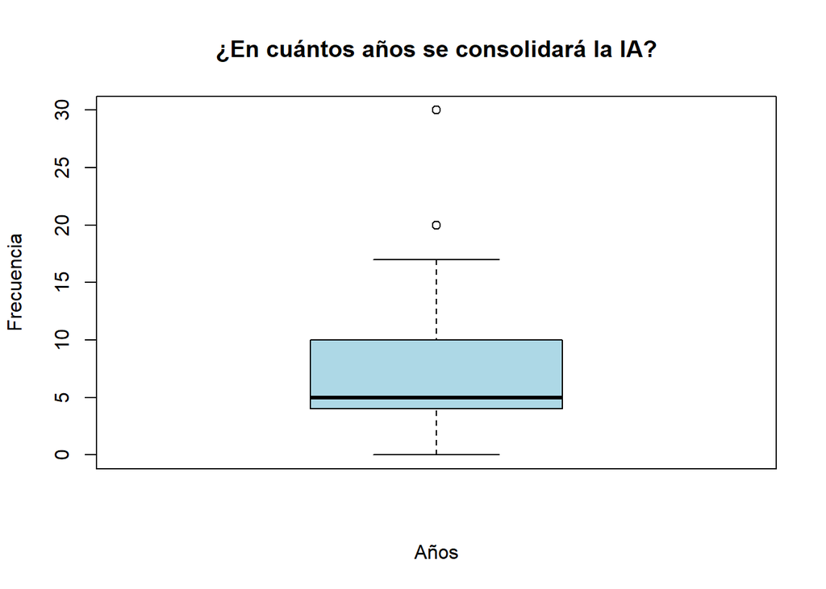

```r
años_sin_atipico<-(BD$Años_consolidacion<50)
Demo<-BD$Años_consolidacion
Demo<-Demo[años_sin_atipico]
Años_cons<-boxplot(Demo,col="lightblue",main="¿En cuántos años se consolidará la IA?",xlab="Años",ylab="Frecuencia")
```

```r
Años_cons
```

```
## $stats
##      [,1]
## [1,]    0
## [2,]    4
## [3,]    5
## [4,]   10
## [5,]   17
##
## $n
## [1] 172
##
## $conf
##          [,1]
## [1,] 4.277157
## [2,] 5.722843
##
## $out
## [1] 20 20 30 20 20 20
##
## $group
## [1] 1 1 1 1 1 1
##
## $names
## [1] ""
```

*Gráfico 12.1: ¿En cuántos años se consolidará la IA?-2*

### Interpretación

Al rehacer el gráfico y anular los valores de 50 y 100 años, nos encontramos con un mínimo de 2 datos atípicos, los cuales son 20 y 30. Además, vemos que la mediana es 5 y el máximo de años en los que los estudiantes creen que la IA se consolidará como un método confiable de diagnóstico/tratamiento es 17 años. (Sin contar datos atípicos)

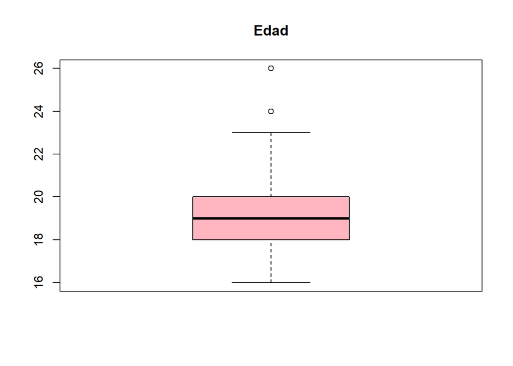

```r
grafico_edad<-boxplot(BD$Edad,col="lightpink",main="Edad")
```

*Gráfico 13: Edad de los encuestados*

```r
grafico_edad
```

```
## $stats
##      [,1]
## [1,]   16
## [2,]   18
## [3,]   19
## [4,]   20
## [5,]   23
##
## $n
## [1] 183
##
## $conf
##          [,1]
## [1,] 18.76641
## [2,] 19.23359
##
## $out
## [1] 24 24 26
##
## $group
## [1] 1 1 1
##
## $names
## [1] ""
```

### Interpretación

Observamos que la mediana es 19, el dato mínimo es 16 y el máximo (sin contar los datos atípicos) es 23. Vemos que hay 2 datos atípicos que son 24 y 26.

```r
a3<-as.integer(count(BD %>% filter(Interes_desarrollo_IA=="Sí")))
b3<-as.integer(count(BD %>% filter(Interes_desarrollo_IA=="No")))
c3<-as.integer(count(BD %>% filter(Interes_desarrollo_IA=="Tal vez")))
d3<-as.integer(count(BD %>% filter(Disposicion_ser_atendido=="Sí")))
e3<-as.integer(count(BD %>% filter(Disposicion_ser_atendido=="No")))
f3<-as.integer(count(BD %>% filter(Disposicion_ser_atendido=="Tal vez")))
Respuestas_binarias<-c(a3,b3,c3,d3,e3,f3)
matriz<-matrix(Respuestas_binarias,nrow=3,ncol=2)
colnames(matriz) <- c("Interés", "Disposición")
rownames(matriz) <- c("Sí", "No","Tal vez")
```

```r
matriz<-as.numeric(matriz)
dim(matriz)<-c(3,2)
colnames(matriz)<-c("Interés en el desarrollo de IA para la medicina","Disposición de ser atendido por una IA")
```

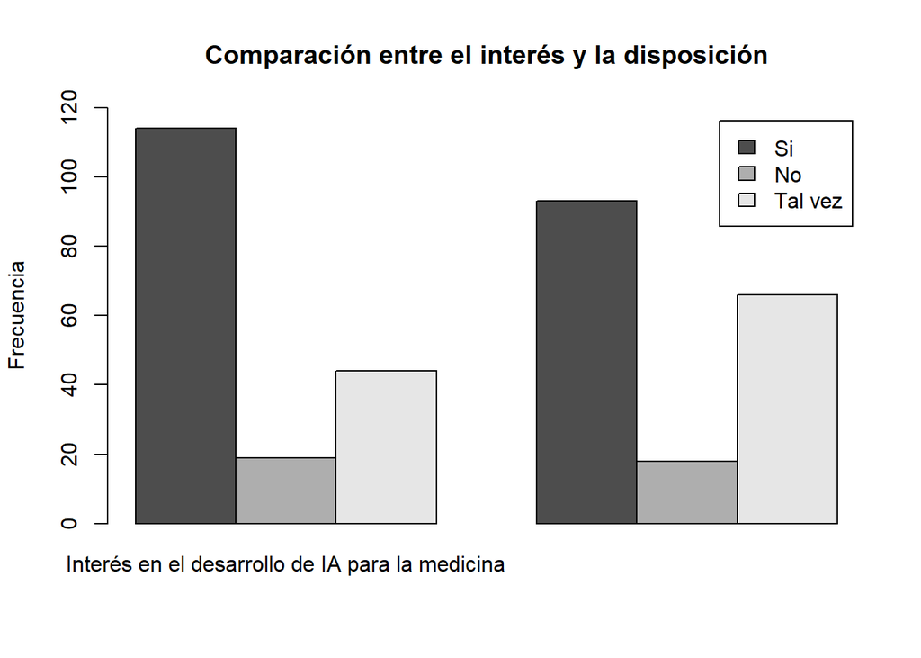

```r
barplot(matriz,legend.text = c("Si","No","Tal vez"),beside=TRUE,main="Comparación entre el interés y la disposición",ylim=c(0,120),ylab="Frecuencia")
```

*Gráfico 14: Comparación entre el interés y la disposición*

Nota: Fueron utilizadas 177 de 183 observaciones para la realización de este gráfico debido a que 6 encuestados no han escuchado sobre la IA y por ende, no tienen una respuesta a esta pregunta.

### Interpretación

Vemos que en ambos casos las respuestas negativas son muy similares. Sin embargo, hay más incertidumbre en cuanto a la disposición de ser atendido que en el interés de participar en el desarrollo de la IA, debido a que hay más personas que “tal vez” dejarían que una IA los atendiera ante una futura patología.